# Phase1

## Import Essentials

```python
# Essentials
import numpy as np
import pandas as pd
import datetime
from sklearn import datasets
from typing import Tuple
from sklearn.manifold import TSNE
from numpy import reshape
import seaborn as sns


# Plots
import seaborn as sns
import matplotlib.pyplot as plt
import matplotlib.cm as cm
%matplotlib inline

# Models

# Stats
from scipy.stats import skew, norm
from scipy.special import boxcox1p
from scipy.stats import boxcox_normmax

# Misc
from sklearn.decomposition import PCA

# Ignore useless warnings
import warnings
warnings.filterwarnings(action="ignore")
pd.options.display.max_seq_items = 8000
pd.options.display.max_rows = 8000

if not sys.warnoptions:
    warnings.simplefilter("ignore")
warnings.filterwarnings('ignore')

import os
from sklearn.cluster import KMeans
from sklearn.metrics.cluster import contingency_matrix
from sklearn.metrics.cluster import silhouette_score
from sklearn.metrics import silhouette_samples

# data visualization
from yellowbrick.cluster import KElbowVisualizer # cluster visualizer

# sklearn kmeans
from sklearn.cluster import KMeans
from sklearn.metrics.cluster import contingency_matrix
from sklearn.metrics.cluster import silhouette_score

# pyclustering kmeans
from pyclustering.cluster.kmeans import kmeans
from pyclustering.utils.metric import distance_metric
from pyclustering.cluster.center_initializer import random_center_initializer
from pyclustering.cluster.encoder import type_encoding
from pyclustering.cluster.encoder import cluster_encoder
```

## Load Datasets

```python
def load_data(train_data: bool =True) -> Tuple[np.ndarray, np.ndarray]:
  """
  loads train/test features with image labels.
  """
  if train_data:
    data = np.load(f'train_data.npz')
  else:
    data = np.load(f'test_data.npz')

  features = data['features']
  img_labels = data['img_labels']

  return features, img_labels

def load_data_with_domain_label() -> Tuple[np.ndarray, np.ndarray]:
  """
  loads portion of training features with domain label
  """
  data = np.load(f'train_data_w_label.npz')
  train_features = data['features']
  domain_labels = data['domain_labels']

  return train_features, domain_labels

### Train Data with image labels
train_features, image_labels = load_data(True)
# print(train_features)
# print(image_labels)
df = pd.DataFrame(train_features)
df["image label"] = image_labels

### Test Data with image labels
test_features, test_image_labels = load_data(False)
# print(test_features.shape)
# print(image_labels.shape)

## 5% of train data with domain label
last_train_features, domain = load_data_with_domain_label()
# print(train_features.shape)
# print(image_labels.shape)
```

```python
df
```

|  | 0 | 1 | 2 | 3 | 4 | 5 | 6 | 7 | 8 | 9 | ... | 2039 | 2040 | 2041 | 2042 | 2043 | 2044 | 2045 | 2046 | 2047 | image label |
| --- | --- | --- | --- | --- | --- | --- | --- | --- | --- | --- | --- | --- | --- | --- | --- | --- | --- | --- | --- | --- | --- |
| 0 | 0.720822 | 0.798316 | 1.470631 | 0.924329 | 0.862209 | -0.627432 | 0.657124 | 0.461108 | 1.049356 | 0.119728 | ... | 0.562979 | 0.153980 | 0.712437 | -0.122676 | 0.120342 | -0.116187 | -0.544742 | 0.030495 | 0.183768 | 1 |
| 1 | -0.225751 | -0.218309 | -0.176653 | -0.317139 | -1.570524 | 0.141231 | -0.853337 | -0.902131 | -0.442563 | -0.129281 | ... | -0.736940 | -0.098002 | -0.936855 | -0.227698 | 0.066659 | 0.362483 | -0.021511 | -0.358628 | 0.197777 | 4 |
| 2 | -0.746808 | -0.997318 | -0.915600 | -0.293238 | -0.535997 | -0.528095 | -0.600580 | 0.728167 | 0.345165 | -0.813821 | ... | -0.168323 | -0.342006 | 0.288280 | -1.552308 | -1.335931 | 0.115971 | -0.907908 | -0.815458 | -0.233952 | 6 |
| 3 | 1.981448 | -1.687241 | 0.859942 | 0.802463 | -2.397170 | 0.383999 | 1.547139 | -0.256686 | 0.018433 | 0.488732 | ... | -0.958578 | -2.006649 | -1.860946 | -0.707069 | 1.188492 | 1.954148 | -1.014899 | -0.824799 | 1.197715 | 4 |
| 4 | -0.433214 | -1.365760 | -0.083440 | -0.167953 | -0.897774 | 1.013131 | 0.063484 | 0.170652 | 0.506950 | 0.070961 | ... | -0.859814 | -0.871730 | -0.717578 | -1.001133 | -0.019569 | 0.588380 | -0.715460 | -1.432113 | 0.917098 | 7 |
| ... | ... | ... | ... | ... | ... | ... | ... | ... | ... | ... | ... | ... | ... | ... | ... | ... | ... | ... | ... | ... | ... |
| 19995 | 0.582671 | 0.544728 | 0.181467 | 0.392197 | 0.325141 | 0.171495 | 0.357492 | 0.072542 | -0.833587 | 2.194538 | ... | 0.910085 | 0.402050 | 0.606412 | -0.070746 | 0.599894 | -0.367257 | 0.646517 | 0.467874 | 0.441449 | 0 |
| 19996 | -0.320465 | -1.095377 | -1.027244 | -0.401039 | -0.721069 | -1.025841 | -0.478751 | -0.423148 | -0.377015 | -1.052589 | ... | -0.110129 | -0.305694 | -1.098195 | -0.551712 | -0.435391 | 0.942207 | -1.439458 | -1.120437 | 0.279119 | 8 |
| 19997 | -1.001775 | -0.649520 | -0.247843 | -0.040057 | -1.053253 | 0.166708 | -0.873535 | 0.012931 | 0.356043 | -0.819597 | ... | -0.035748 | -0.187255 | -1.136602 | -0.489721 | -1.149233 | -0.035817 | -0.371619 | -1.151720 | 0.470592 | 9 |
| 19998 | -0.571462 | 0.184719 | -0.735875 | -0.697468 | 0.531802 | -0.280673 | -0.448684 | 0.773326 | 0.397695 | -0.397464 | ... | 0.171218 | 0.727045 | 0.460090 | -0.415633 | -1.876864 | -0.760399 | 0.204750 | -0.254483 | 0.337292 | 0 |
| 19999 | -0.177254 | -0.274863 | -0.731820 | 0.298803 | -0.008910 | -0.600867 | -0.859067 | 0.336200 | 0.674287 | -0.288580 | ... | -0.165522 | 0.266437 | -0.424631 | -1.687144 | -1.429724 | -0.387522 | -0.592792 | -0.913986 | -0.054667 | 0 |

20000 rows × 2049 columns

```python
# scale = StandardScaler()
# X = scale.fit_transform(train_features)
# X.shape
```

```python
# n_clusters=10
# cost=[]
# for i in range(1,n_clusters):
#     kmean= KMeans(i)
#     kmean.fit(X)
#     cost.append(kmean.inertia_)
```

```python
# plt.plot(cost, 'bx-')
```

# Model Selection

## Dbscan

```python
from sklearn.cluster import DBSCAN
db=DBSCAN(eps=3,min_samples=4,metric='euclidean')
model=db.fit(train_features)
label=model.labels_
```

```python
y_means = db.fit_predict(train_features)
```

[figure not shown]

```python
# Apply t-SNE to reduce the dimensionality of the data to 2D
tsne = TSNE(n_components=2, perplexity=30, learning_rate=200)
X_tsne = tsne.fit_transform(train_features)

# Plot the clusters in 2D using different colors for each cluster
plt.scatter(X_tsne[:, 0], X_tsne[:, 1], c=label)
plt.show()
```

[output not shown]

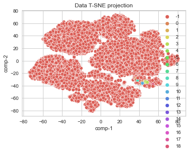

```python
tsne = TSNE(n_components=2, verbose=1, random_state=123)
z = tsne.fit_transform(train_features)
df = pd.DataFrame()
df["y"] = label
df["comp-1"] = z[:, 0]
df["comp-2"] = z[:, 1]

sns.scatterplot(x="comp-1", y="comp-2", hue=df.y.tolist(),
                palette=sns.color_palette("hls", len(np.unique(label))),
                data=df).set(title="Data T-SNE projection")
import matplotlib.pyplot as plt
plt.show()
```

### Oh No, Another clustering method please!

```python
# from sklearn import metrics
# #identifying the points which makes up our core points
# sample_cores=np.zeros_like(label,dtype=bool)
# sample_cores[db.core_sample_indices_]=True
# #Calculating the number of clusters
# n_clusters=len(set(label))- (1 if -1 in label else 0)
# print('No of clusters:',n_clusters)
```

## Dendrogram

#### Here we generate a dendrogram (a tree-like diagram) using hierarchical clustering on the training features data. The method used for clustering is "ward", which minimizes the variance between clusters. The dendrogram shows how the data points are grouped together based on their similarity in terms of their features.

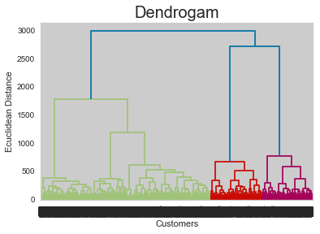

```python
import scipy.cluster.hierarchy as sch

dendrogram = sch.dendrogram(sch.linkage(train_features, method = 'ward'))
plt.title('Dendrogam', fontsize = 20)
plt.xlabel('Customers')
plt.ylabel('Ecuclidean Distance')
plt.show()
```

## Agglomerative

```python
from sklearn.cluster import AgglomerativeClustering
clustering = AgglomerativeClustering().fit(train_features)
clustering.labels_
```

```
array([0, 0, 1, ..., 1, 1, 1], dtype=int64)
```

```python
from scipy.cluster.hierarchy import dendrogram

# def plot_dendrogram(model, **kwargs):
#     # Create linkage matrix and then plot the dendrogram

#     # create the counts of samples under each node
#     counts = np.zeros(model.children_.shape[0])
#     n_samples = len(model.labels_)
#     for i, merge in enumerate(model.children_):
#         current_count = 0
#         for child_idx in merge:
#             if child_idx < n_samples:
#                 current_count += 1  # leaf node
#             else:
#                 current_count += counts[child_idx - n_samples]
#         counts[i] = current_count

#     linkage_matrix = np.column_stack([model.children_, model.distances_,
#                                       counts]).astype(float)

#     # Plot the corresponding dendrogram
#     dendrogram(linkage_matrix, **kwargs)

# model = AgglomerativeClustering(distance_threshold=0, n_clusters=None)
# model.fit(train_features)

# plt.figure(fignum, figsize=(10, 6))
# plt.title('Hierarchical Clustering Dendrogram')
# # plot the top three levels of the dendrogram
# plot_dendrogram(model, truncate_mode='level', p=3)
# plt.xlabel("Number of points in node (or index of point if no parenthesis).")
# plt.show()

# print(model.n_clusters)
```

```python
## tedad cluster ha ro print konam bebinam chand
```

```python
# from sklearn.cluster import SpectralClustering
# model = SpectralClustering(n_clusters=2, affinity='nearest_neighbors', assign_labels='kmeans').fit(train_features)
# from sklearn.datasets import make_moons
# X3, y3 = make_moons(250, noise=.075, random_state=22)

# for i in range(6):
#     single = SpectralClustering(n_clusters=i, affinity='nearest_neighbors', assign_labels='kmeans')
#     labels = single.fit_predict(X3)
#     plt.scatter(X3[:, 0], X3[:, 1], c=labels, s=50, cmap='cividis')
```

## Kmeans

#### Here we splitted data set into 10 subdatasets. According to their 'image_label'-That has 10 Unique values. The idea is to use those 'image_labels' during the proccess of clustering to achive a better accuracy and a better view of 'Domains'. Then, we have re-clustered each of these subsets on different values of 'k' and finally picking the most frequent 'optimom K' as a good 'K' for our main 'Domain Clustering'.

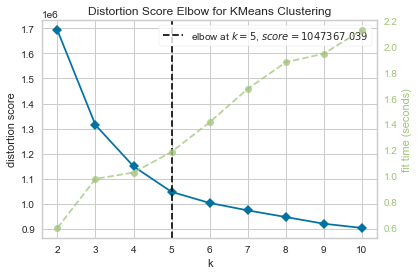

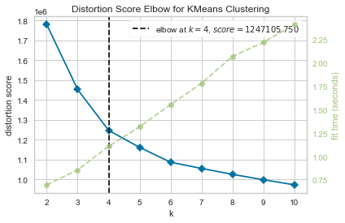

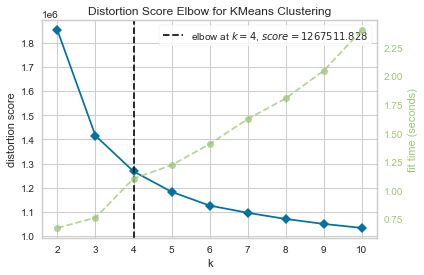

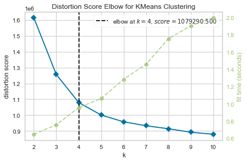

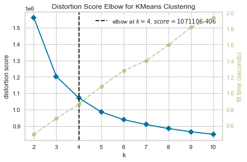

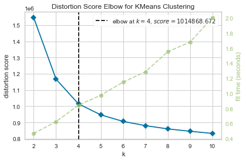

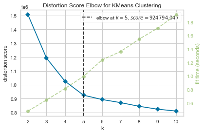

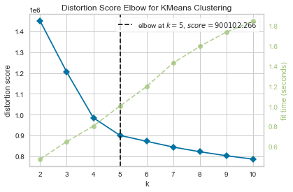

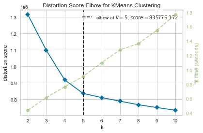

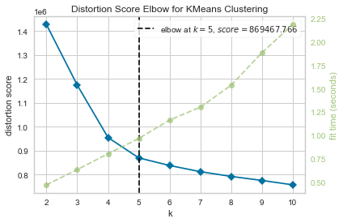

```python
score=[]
for i in range(0,10):
    new_df = df.loc[df["image label"] == i]
    new_df = new_df.iloc[:, 0:-1]
    kmeans = KMeans()
    visualize = KElbowVisualizer(kmeans, k = (2,11))
    visualize.fit(new_df)
    score.append(visualize.elbow_value_)
    visualize.show()
plt.show()
```

### General clustering

```python
km_model = KMeans(n_clusters=5, random_state=10)
labels = km_model.fit(train_features)
predicted = km_model.predict(last_train_features)
```

## Evaluation

### Checking the quality of algorithm for Domain recognition

```python
print(metrics.homogeneity_score(domain, predicted))
print(metrics.completeness_score(domain, predicted))
print(metrics.v_measure_score(domain, predicted))
print(metrics.adjusted_rand_score(domain, predicted))
print(metrics.rand_score(domain, predicted))
print(metrics.mutual_info_score(domain, predicted))
print(metrics.adjusted_mutual_info_score(domain, predicted,
                                         average_method='arithmetic'))
print(metrics.calinski_harabasz_score(last_train_features, predicted))
print(metrics.davies_bouldin_score(last_train_features, predicted))
```

```
0.8050311344182404
0.8192481800080841
0.8120774375002382
0.7543809840079696
0.9196876876876877
1.2940558729297236
0.8111230229534081
240.0523765008292
1.8717350918777054
```

### Checking the quality of clustering model, on the test data with its labels

```python
test_predicted = km_model.predict(test_features)
print(metrics.rand_score(test_image_labels, test_predicted))
```

```
0.7292654665466547
```

### Now, Lets Visualize the above data clusterings, with t-sne.

[output not shown]

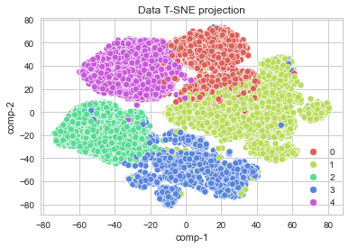

```python
tsne = TSNE(n_components=2, verbose=1, random_state=123)
z = tsne.fit_transform(train_features)
df = pd.DataFrame()
df["y"] = labels
df["comp-1"] = z[:, 0]
df["comp-2"] = z[:, 1]

sns.scatterplot(x="comp-1", y="comp-2", hue=df.y.tolist(),
                palette=sns.color_palette("hls", 5),
                data=df).set(title="Data T-SNE projection")
import matplotlib.pyplot as plt
plt.show()
```

### Seems good. But lets check another trick. Here we first apply a kmeans model to 'Over Cluster' and then try a Agglomerative clustering to 'merge' some clusters that are close to each other.

```python
# Apply k-means clustering with 12 clusters
kmeans = KMeans(n_clusters=12)
labels = kmeans.fit_predict(train_features)

# Apply agglomerative clustering to merge the clusters
agg_clustering = AgglomerativeClustering(n_clusters=5, linkage='ward')
merged_labels = agg_clustering.fit_predict(kmeans.cluster_centers_)

# Map the merged labels back to the original data points
merged_labels_all = np.zeros_like(labels)
for i in range(12):
    merged_labels_all[labels == i] = merged_labels[i]

print(merged_labels_all)
```

```
[0 1 2 ... 4 2 2]
```

### Lets apply a 'PCA' to visualize this dataset

```python
from sklearn.metrics.pairwise import cosine_similarity
dist = 1 - cosine_similarity(train_features)
pca = PCA(2)
pca.fit(dist)
X_PCA = pca.transform(dist)
X_PCA.shape
```

```
(20000, 2)
```

[figure not shown]

```python
x, y = X_PCA[:, 0], X_PCA[:, 1]

colors = {0: 'red',
          1: 'blue',
          2: 'green',
          3: 'yellow',
          4: 'purple'}

names = {0: 'firts label',
         1: 'second label',
         2: 'third label',
         3: 'forth label',
         4: 'fifth label'}

df = pd.DataFrame({'x': x, 'y':y, 'label':merged_labels_all})
groups = df.groupby('label')

fig, ax = plt.subplots(figsize=(20, 13))

for name, group in groups:
    ax.plot(group.x, group.y, marker='o', linestyle='', ms=5,
            color=colors[name],label=names[name], mec='none')
    ax.set_aspect('auto')
    ax.tick_params(axis='x',which='both',bottom='off',top='off',labelbottom='off')
    ax.tick_params(axis= 'y',which='both',left='off',top='off',labelleft='off')

ax.legend()
ax.set_title("Customers Segmentation based on their Credit Card usage bhaviour.")
plt.show()
```

### T-sne

```python
# tsne = TSNE(n_components=2, verbose=1, random_state=123)
# e = tsne.fit_transform(train_features)
# df1 = pd.DataFrame()
# df1["y"] = merged_labels_all
# df1["comp-1"] = e[:, 0]
# df1["comp-2"] = e[:, 1]

# sns.scatterplot(x="comp-1", y="comp-2", hue=df.y.tolist(),
#                 palette=sns.color_palette("hls", 5),
#                 data=df1).set(title="Data T-SNE projection")
# import matplotlib.pyplot as plt
# plt.show()
```

### Another implementation of overclustering + merging similar clusters

```python
# import numpy as np
# from sklearn.cluster import KMeans, AgglomerativeClustering
# # Generate some random data

# # Perform initial clustering with KMeans
# # kmeans = KMeans(n_clusters=5)
# # labels = kmeans.fit_predict(train_features)

# # Overcluster by increasing the number of clusters
# over_labels = KMeans(n_clusters=12).fit_predict(last_train_features)

# # Create a new distance matrix based on the overclustered labels
# dist_matrix = np.zeros((len(over_labels), len(over_labels)))
# for i in range(len(over_labels)):
#     for j in range(len(over_labels)):
#         if i != j:
#             if over_labels[i] == over_labels[j]:
#                 dist_matrix[i][j] = 0
#             else:
#                 dist_matrix[i][j] = 1

# # Perform hierarchical clustering on the new distance matrix
# hierarchical = AgglomerativeClustering(n_clusters=5, affinity='precomputed', linkage='complete')
# new_labels = hierarchical.fit_predict(dist_matrix)

# print("Initial labels:", labels)
# print("Overclustered labels:", over_labels)
# print("New labels after hierarchy clustering:", new_labels)
```

```python
# print(metrics.silhouette_score(image_labels.reshape(-1, 1), new_labels.reshape(-1, 1)))
# print(metrics.homogeneity_score(image_labels, new_labels))
# print(metrics.completeness_score(image_labels, new_labels))
# print(metrics.v_measure_score(image_labels, new_labels))
# print(metrics.adjusted_rand_score(image_labels, new_labels))
# print(metrics.rand_score(image_labels, new_labels))
# print(metrics.mutual_info_score(image_labels, new_labels))
# print(metrics.adjusted_mutual_info_score(image_labels, new_labels,
#                                          average_method='arithmetic'))
# print(metrics.calinski_harabasz_score(train_features, new_labels))
# print(metrics.davies_bouldin_score(train_features, new_labels))
```

[figure not shown]

```python
# Visualizing the clustering
# plt.scatter(df["comp-1"], df["comp-2"],
#            c = AgglomerativeClustering(n_clusters = 5).fit_predict(X), cmap =plt.cm.winter)
# plt.show()
```